# 背景与目的

# 数据处理

```python
%matplotlib inline
import pandas as pd
import numpy as np
from scipy import stats
import matplotlib.pyplot as plt
import seaborn as sns
import re
import pandas_profiling
import warnings
import my_functions as my
import datetime
warnings.filterwarnings('ignore')
from matplotlib.font_manager import FontProperties
from matplotlib import rcParams
sns.set_style("ticks") # dark/white/darkgrid/whitegrid
```

## listing表的诊断与清洗

```python
df1=my.reduce_mem_usage(pd.read_csv("listings.csv"))
df2=my.reduce_mem_usage(pd.read_csv("reviews_detail.csv"))
```

```
Memory usage of dataframe is 3641984.00 MB
Memory usage after optimization is: 3156184.00 MB
Decreased by 13.3%
Memory usage of dataframe is 9700880.00 MB
Memory usage after optimization is: 14435538.00 MB
Decreased by -48.8%
```

```python
df1.head() #查看大体上是否不干净的数据
```

|  | id | name | host_id | host_name | neighbourhood_group | neighbourhood | latitude | longitude | room_type | price | minimum_nights | number_of_reviews | last_review | reviews_per_month | calculated_host_listings_count | availability_365 |
| --- | --- | --- | --- | --- | --- | --- | --- | --- | --- | --- | --- | --- | --- | --- | --- | --- |
| 0 | 44054 | Modern and Comfortable Living in CBD | 192875 | East Apartments | NaN | 朝阳区 / Chaoyang | 39.90625 | 116.4375 | Entire home/apt | 792 | 1 | 89 | 2019-03-04 | 0.850098 | 9 | 341 |
| 1 | 100213 | The Great Wall Box Deluxe Suite A团园长城小院东院套房 | 527062 | Joe | NaN | 密云县 / Miyun | 40.68750 | 117.1875 | Private room | 1201 | 1 | 2 | 2017-10-08 | 0.099976 | 4 | 0 |
| 2 | 128496 | Heart of Beijing: House with View 2 | 467520 | Cindy | NaN | 东城区 | 39.93750 | 116.4375 | Entire home/apt | 389 | 3 | 259 | 2019-02-05 | 2.699219 | 1 | 93 |
| 3 | 161902 | cozy studio in center of Beijing | 707535 | Robert | NaN | 东城区 | 39.93750 | 116.4375 | Entire home/apt | 376 | 1 | 26 | 2016-12-03 | 0.280029 | 5 | 290 |
| 4 | 162144 | nice studio near subway, sleep 4 | 707535 | Robert | NaN | 朝阳区 / Chaoyang | 39.93750 | 116.4375 | Entire home/apt | 537 | 1 | 37 | 2018-08-01 | 0.399902 | 5 | 352 |

name和neighbourhood中英文混合，需要进一步清洗。

```python
df1.info()
```

```
<class 'pandas.core.frame.DataFrame'>
RangeIndex: 28452 entries, 0 to 28451
Data columns (total 16 columns):
 #   Column                          Non-Null Count  Dtype
---  ------                          --------------  -----
 0   id                              28452 non-null  int32
 1   name                            28451 non-null  category
 2   host_id                         28452 non-null  int32
 3   host_name                       28452 non-null  category
 4   neighbourhood_group             0 non-null      float64
 5   neighbourhood                   28452 non-null  category
 6   latitude                        28452 non-null  float16
 7   longitude                       28452 non-null  float16
 8   room_type                       28452 non-null  category
 9   price                           28452 non-null  int32
 10  minimum_nights                  28452 non-null  int16
 11  number_of_reviews               28452 non-null  int16
 12  last_review                     17294 non-null  category
 13  reviews_per_month               17294 non-null  float16
 14  calculated_host_listings_count  28452 non-null  int16
 15  availability_365                28452 non-null  int16
dtypes: category(5), float16(3), float64(1), int16(4), int32(3)
memory usage: 3.0 MB
```

```python
my.Nullrate(df1)
```

|  | 0 | nullrate | nullrate% |
| --- | --- | --- | --- |
| neighbourhood_group | 28452 | 1.000000 | 100.00 |
| reviews_per_month | 11158 | 0.392169 | 39.22 |
| last_review | 11158 | 0.392169 | 39.22 |
| name | 1 | 0.000035 | 0.00 |

```python
df1.drop("neighbourhood_group",axis=1,inplace=True) #移除neighbourhood_group
df1.id=df1.id.astype("category") #数据类型转换
df1.host_id=df1.host_id.astype("category") #数据类型转换
df1.last_review=pd.to_datetime(df1.last_review) #数据类型转换
df1["year"]=df1.last_review.dt.year #日期数据钻取，以便时间序列分析
df1["month"]=df1.last_review.dt.month
df1["weekday"]=df1.last_review.dt.weekday #返回周几
```

```python
from chinese_calendar import is_workday, is_holiday,is_in_lieu  #判断日期是否工作日；节假日；调休
#由于时间序列数据是德国的日历；因此不能用中国日历来创建特征。
creat_time=pd.to_datetime(df1.last_review, errors='coerce')
df1["is_workday"]=creat_time.apply(lambda x:is_workday(x) )
df1["is_holiday"]=creat_time.apply(lambda x:is_holiday(x) )
df1["is_in_lieu"]=creat_time.apply(lambda x:is_in_lieu(x) )
```

```python
df1.head()
```

|  | id | name | host_id | host_name | neighbourhood | latitude | longitude | room_type | price | minimum_nights | ... | last_review | reviews_per_month | calculated_host_listings_count | availability_365 | year | month | weekday | is_workday | is_holiday | is_in_lieu |
| --- | --- | --- | --- | --- | --- | --- | --- | --- | --- | --- | --- | --- | --- | --- | --- | --- | --- | --- | --- | --- | --- |
| 0 | 44054 | Modern and Comfortable Living in CBD | 192875 | East Apartments | 朝阳区 / Chaoyang | 39.90625 | 116.4375 | Entire home/apt | 792 | 1 | ... | 2019-03-04 | 0.850098 | 9 | 341 | 2019.0 | 3.0 | 0.0 | True | False | False |
| 1 | 100213 | The Great Wall Box Deluxe Suite A团园长城小院东院套房 | 527062 | Joe | 密云县 / Miyun | 40.68750 | 117.1875 | Private room | 1201 | 1 | ... | 2017-10-08 | 0.099976 | 4 | 0 | 2017.0 | 10.0 | 6.0 | False | True | False |
| 2 | 128496 | Heart of Beijing: House with View 2 | 467520 | Cindy | 东城区 | 39.93750 | 116.4375 | Entire home/apt | 389 | 3 | ... | 2019-02-05 | 2.699219 | 1 | 93 | 2019.0 | 2.0 | 1.0 | False | True | False |
| 3 | 161902 | cozy studio in center of Beijing | 707535 | Robert | 东城区 | 39.93750 | 116.4375 | Entire home/apt | 376 | 1 | ... | 2016-12-03 | 0.280029 | 5 | 290 | 2016.0 | 12.0 | 5.0 | False | True | False |
| 4 | 162144 | nice studio near subway, sleep 4 | 707535 | Robert | 朝阳区 / Chaoyang | 39.93750 | 116.4375 | Entire home/apt | 537 | 1 | ... | 2018-08-01 | 0.399902 | 5 | 352 | 2018.0 | 8.0 | 2.0 | True | False | False |

5 rows × 21 columns

### 分类特征

```python
df1.describe(include=["O"]) #查看分类型数据统计结果
```

|  | is_workday | is_holiday | is_in_lieu |
| --- | --- | --- | --- |
| count | 17294 | 17294 | 17294 |
| unique | 2 | 2 | 2 |
| top | False | True | False |
| freq | 8877 | 8877 | 16788 |

```python
df1.neighbourhood.value_counts()
df1=df1[df1.name.notnull()]
```

数据格式不统一，中英混合或纯中文，因此可以考虑滤除非汉字部分，统一数据格式。

```python
df1["neighbourhood"]=df1["neighbourhood"].apply(lambda x:re.sub("[A-Za-z0-9/]", "",x)) #滤除非汉字部分
df1["neighbourhood"]=df1["neighbourhood"].apply(lambda x:re.sub("县", "区",x)) #替换
df1["neighbourhood"]=df1["neighbourhood"].apply(lambda x:re.sub(" ", "",x)) #消除空格
```

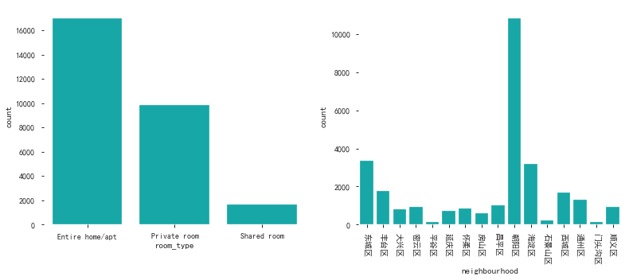

```python
#计数条形图，获取分类数据大致分布情况
category_item=['room_type','neighbourhood']
fig,axes=plt.subplots(1,len(category_item),figsize=(13,5))
plt.subplots_adjust(hspace=1)
plt.xticks(rotation=-90)
plt.rcParams['font.sans-serif']=['SimHei'] #用来正常显示中文标签
for i,subset in enumerate(category_item):
    sns.countplot(x=df1[subset],ax=axes[i],color="c")
```

### 数值特征

```python
df1.describe(percentiles=[0.05,0.25,0.5,0.75,0.95]) #数值型数据统计结果
```

|  | latitude | longitude | price | minimum_nights | number_of_reviews | reviews_per_month | calculated_host_listings_count | availability_365 | year | month | weekday |
| --- | --- | --- | --- | --- | --- | --- | --- | --- | --- | --- | --- |
| count | 28451.00000 | 2.845100e+04 | 28451.000000 | 28451.000000 | 28451.000000 | 17294.000000 | 28451.000000 | 28451.000000 | 17294.000000 | 17294.000000 | 17294.000000 |
| mean | inf | inf | 610.873396 | 2.729746 | 7.103406 | 1.320312 | 12.818706 | 220.337071 | 2018.589164 | 4.840985 | 3.527640 |
| std | 0.18811 | 2.055664e-01 | 1622.609504 | 17.921244 | 16.815310 | 1.581055 | 29.261751 | 138.430490 | 0.650965 | 3.072522 | 2.163666 |
| min | 39.46875 | 1.155000e+02 | 0.000000 | 1.000000 | 0.000000 | 0.010002 | 1.000000 | 0.000000 | 2012.000000 | 1.000000 | 0.000000 |
| 5% | 39.81250 | 1.161875e+02 | 107.000000 | 1.000000 | 0.000000 | 0.090027 | 1.000000 | 0.000000 | 2017.000000 | 1.000000 | 0.000000 |
| 25% | 39.90625 | 1.163750e+02 | 235.000000 | 1.000000 | 0.000000 | 0.290039 | 2.000000 | 87.000000 | 2018.000000 | 3.000000 | 2.000000 |
| 50% | 39.93750 | 1.164375e+02 | 389.000000 | 1.000000 | 1.000000 | 0.799805 | 5.000000 | 209.000000 | 2019.000000 | 4.000000 | 4.000000 |
| 75% | 40.00000 | 1.165000e+02 | 577.000000 | 1.000000 | 6.000000 | 1.750000 | 11.000000 | 361.000000 | 2019.000000 | 7.000000 | 6.000000 |
| 95% | 40.43750 | 1.166875e+02 | 1691.000000 | 5.000000 | 35.000000 | 4.519531 | 45.000000 | 365.000000 | 2019.000000 | 11.000000 | 6.000000 |
| max | 40.93750 | 1.175000e+02 | 68983.000000 | 1125.000000 | 322.000000 | 20.000000 | 222.000000 | 365.000000 | 2019.000000 | 12.000000 | 6.000000 |

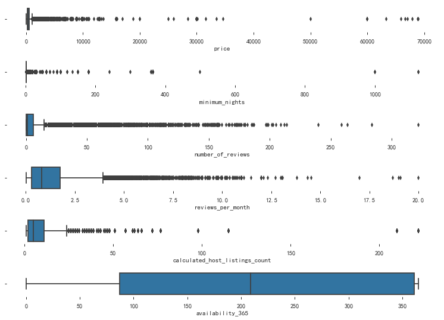

```python
#箱型图，获取数据大致分布情况，查看离群点信息
subsets=['price','minimum_nights','number_of_reviews','reviews_per_month','calculated_host_listings_count','availability_365']
fig,axes=plt.subplots(len(subsets),1,figsize=(13,9))
plt.subplots_adjust(hspace=1)
for i,subset in enumerate(subsets):
    sns.boxplot(df1[subset],ax=axes[i],orient='h')
```

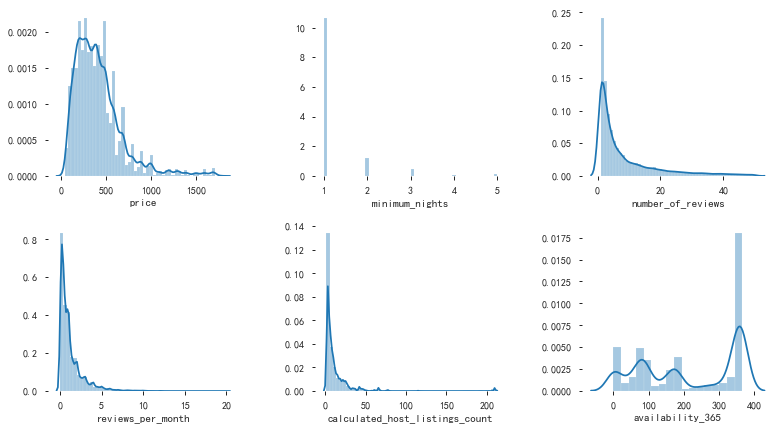

```python
#直方图，获取数据大致分布情况，查看集中信息
fig2,[[ax1,ax2,ax3],[ax4,ax5,ax6]]=plt.subplots(2,3,figsize=(13,7))
axes2=[ax1,ax2,ax3,ax4,ax5,ax6]
plt.subplots_adjust(hspace=.3, wspace=.4)
data=df1[(df1.price<=1778) & (df1.minimum_nights<=5) & (df1.number_of_reviews<=50)]
data=data.dropna(how="any")
for i,subset in enumerate(subsets):
    sns.distplot(data[subset],ax=axes2[i])
```

price为0的记录考虑删除，价格极差很大，标准差系数达到2.65，对于高于10000的记录需要进一步诊断是否异常，价格很高有可能房源是别墅等豪宅。 minimum_nights：95%在5以内，99%在30以内，最大值达到1125，意味着这个房源至少需要连续订阅1125个晚上，与常理不是很吻合,需要进一步诊断。 number_of_reviews:极差很大，99%位数与max差异也很大，需要查看是否存在异常。 availability_365：应在1~365之间，在此区间外的数据应该删除。

```python
df1[df1.price>=10000].head()
```

|  | id | name | host_id | host_name | neighbourhood | latitude | longitude | room_type | price | minimum_nights | ... | last_review | reviews_per_month | calculated_host_listings_count | availability_365 | year | month | weekday | is_workday | is_holiday | is_in_lieu |
| --- | --- | --- | --- | --- | --- | --- | --- | --- | --- | --- | --- | --- | --- | --- | --- | --- | --- | --- | --- | --- | --- |
| 1067 | 12689987 | Artistic apartment with culture | 68973377 | 晨斌 | 朝阳区 | 39.93750 | 116.5625 | Entire home/apt | 67104 | 1 | ... | 2016-06-03 | 0.059998 | 2 | 365 | 2016.0 | 6.0 | 4.0 | True | False | False |
| 1227 | 13418237 | Great Wall Paradise Villa | 6628610 | Chris | 怀柔区 | 40.46875 | 116.6250 | Entire home/apt | 10066 | 1 | ... | 2019-04-06 | 0.189941 | 1 | 364 | 2019.0 | 4.0 | 5.0 | False | True | False |
| 2012 | 15488817 | Hotel apartment close to huge Mall | 68973377 | 晨斌 | 朝阳区 | 39.90625 | 116.5625 | Entire home/apt | 63346 | 1 | ... | 2017-04-17 | 0.549805 | 2 | 180 | 2017.0 | 4.0 | 0.0 | True | False | False |
| 3427 | 18554424 | 东五环北欧风小两居 | 46923669 | Shirley | 朝阳区 | 39.84375 | 116.5625 | Entire home/apt | 10998 | 1 | ... | NaT | NaN | 2 | 364 | NaN | NaN | NaN | NaN | NaN | NaN |
| 4199 | 19643684 | 观城9号(整院儿 圣泉寺 慕田峪 箭扣长城 红螺寺 响水湖) | 47672470 | 经纬 | 顺义区 | 40.18750 | 116.8750 | Entire home/apt | 33471 | 1 | ... | NaT | NaN | 6 | 360 | NaN | NaN | NaN | NaN | NaN | NaN |

5 rows × 21 columns

```python
df1[df1.price>=10000].room_type.value_counts()
```

```
Entire home/apt    33
Private room       11
Shared room         4
Name: room_type, dtype: int64
```

```python
df1[df1.minimum_nights>=365].head(10)
```

|  | id | name | host_id | host_name | neighbourhood | latitude | longitude | room_type | price | minimum_nights | ... | last_review | reviews_per_month | calculated_host_listings_count | availability_365 | year | month | weekday | is_workday | is_holiday | is_in_lieu |
| --- | --- | --- | --- | --- | --- | --- | --- | --- | --- | --- | --- | --- | --- | --- | --- | --- | --- | --- | --- | --- | --- |
| 1175 | 13183350 | 鸟巢旁欧式罗曼蒂克两居 | 56183837 | Jack | 朝阳区 | 40.00000 | 116.3750 | Entire home/apt | 463 | 1000 | ... | 2016-07-25 | 0.059998 | 1 | 0 | 2016.0 | 7.0 | 0.0 | True | False | False |
| 2192 | 15948304 | 离车公庄地铁5分钟,离新街口步行十分钟｡交通便利｡环境幽雅,安全｡ | 78186433 | Bo | 西城区 | 39.93750 | 116.3750 | Entire home/apt | 376 | 365 | ... | NaT | NaN | 1 | 364 | NaN | NaN | NaN | NaN | NaN | NaN |
| 3227 | 18258080 | 海淀魏公村万寿寺甲3号 3室1厅 160平米(只接受个人年长租) | 122796150 | Xu | 海淀区 | 39.93750 | 116.3125 | Entire home/apt | 550 | 365 | ... | NaT | NaN | 1 | 365 | NaN | NaN | NaN | NaN | NaN | NaN |
| 3313 | 18402988 | Beijing Sunshine place | 96817654 | 宁Ning | 东城区 | 39.90625 | 116.4375 | Entire home/apt | 396 | 365 | ... | 2018-09-30 | 1.179688 | 1 | 364 | 2018.0 | 9.0 | 6.0 | True | False | False |
| 4773 | 20311554 | 京都爱巢,为您准备 | 144803735 | 福春 | 海淀区 | 39.96875 | 116.3125 | Entire home/apt | 490 | 365 | ... | 2017-08-20 | 0.099976 | 2 | 90 | 2017.0 | 8.0 | 6.0 | False | True | False |
| 4836 | 20417131 | 护城河边,观望京都 | 144803735 | 福春 | 海淀区 | 39.90625 | 116.3125 | Entire home/apt | 591 | 365 | ... | NaT | NaN | 2 | 365 | NaN | NaN | NaN | NaN | NaN | NaN |
| 4981 | 20589657 | 爱屋吉屋 | 130855713 | 茜 | 朝阳区 | 39.84375 | 116.5625 | Entire home/apt | 302 | 365 | ... | NaT | NaN | 1 | 362 | NaN | NaN | NaN | NaN | NaN | NaN |
| 5609 | 21098578 | 6号14号线金台路青旅燕儿窝上下铺国贸CBD | 129486966 | 磊 | 朝阳区 | 39.90625 | 116.5000 | Shared room | 121 | 1124 | ... | 2018-08-03 | 0.330078 | 6 | 362 | 2018.0 | 8.0 | 4.0 | True | False | False |
| 5857 | 21319861 | 嵩山居·首都机场店 | 154311879 | 涛 | 昌平区 | 40.09375 | 116.4375 | Private room | 268 | 365 | ... | NaT | NaN | 1 | 364 | NaN | NaN | NaN | NaN | NaN | NaN |
| 6505 | 21841908 | 鸟巢水立方朝南大主卧 | 159278266 | 小梦 | 海淀区 | 40.03125 | 116.3750 | Private room | 255 | 1000 | ... | NaT | NaN | 1 | 0 | NaN | NaN | NaN | NaN | NaN | NaN |

10 rows × 21 columns

分析：有些房源以年来长租，因此可能存在minimum_nights大于365的情况，不是异常，例如：id位18258080的房源。但如果房子年租（minimum_nights>365），且price超过95%分位数则可能是异常数据，考虑移除。

```python
df1=df1[~((df1.price>10000)&(df1.room_type.isin(["Private room","Shared room"]))&(df1.last_review.isnull()))]
df1=df1[~((df1.minimum_nights>365)&(df1.price>df1.price.quantile(q=0.95)))]
df1=df1[df1["price"]>0]
df1=df1[(0<df1["availability_365"]) & (df1["availability_365"]<=365) ]
```

## review表的诊断与清洗

```python
df2.head(3).append(df2.tail(3))
```

|  | listing_id | id | date | reviewer_id | reviewer_name | comments |
| --- | --- | --- | --- | --- | --- | --- |
| 0 | 44054 | 84748 | 2010-08-25 | 207019 | Jarrod | Sev was very helpful. Sev showed us where to ... |
| 1 | 44054 | 118384 | 2010-10-13 | 218723 | Kimberly | We arrived in Beijing very early in the mornin... |
| 2 | 44054 | 436978 | 2011-08-11 | 609177 | Emma | It is a really massive apartment and really co... |
| 202096 | 33891613 | 438182693 | 2019-04-16 | 255994654 | 天佑 | 房间布置明亮温暖而别有风格,指引周到而迅速,房间内设施齐全､空间宽敞! |
| 202097 | 33892088 | 438119657 | 2019-04-16 | 255993753 | 志强 | 各方面这个价位性价比是非常之高了,房东人也很好,交通便利,我个人是很满意的,有机会还会来｡ |
| 202098 | 33925874 | 438572523 | 2019-04-17 | 256375057 | 玲 | The host canceled this reservation 13 days bef... |

```python
df2.info()
```

```
<class 'pandas.core.frame.DataFrame'>
RangeIndex: 202099 entries, 0 to 202098
Data columns (total 6 columns):
 #   Column         Non-Null Count   Dtype
---  ------         --------------   -----
 0   listing_id     202099 non-null  int32
 1   id             202099 non-null  int32
 2   date           202099 non-null  category
 3   reviewer_id    202099 non-null  int32
 4   reviewer_name  202093 non-null  category
 5   comments       201983 non-null  category
dtypes: category(3), int32(3)
memory usage: 13.8 MB
```

data_review异常诊断： reviewer_name和comments 存在一定程度缺失，由于确实比例不是很大，考虑直接移除缺失记录。 date应为日期格式；id、listing_id、reviewer_id应为类别型数据；reviewer_name中英混合，可以想办法进行整合。 comments中英混合，考虑进行拆分，进而做中英文文本情感分析。

```python
df2=df2.dropna(axis=0) #移除有缺失值的行
df2.id=df2.id.astype('object')
df2.reviewer_id=df2.reviewer_id.astype("object")
df2.listing_id=df2.listing_id.astype("object")
df2.date=pd.to_datetime(df2.date)
df2["Chinese_comments"]=df2.comments.apply(lambda x:re.sub("[A-Za-z0-9\!\%\?()./[\]\- 	:;,\。 ' ...r'\n\r\n\r\n'""	 	]", "",str(x))) #滤除非汉字部分
df2["Chinese_comments"]=df2["Chinese_comments"].apply(lambda x : re.sub("","无",x))
df2["English_comments"]=df2.comments.apply(lambda x:re.sub("[\u4e00-\u9fa5...r'\n\r\n\r\n'!""	]", "",str(x))) #滤除汉字部分
```

#### NLP情感倾向统计

```python
from textblob import TextBlob #英文文本情感分析库
def CalPolarity(text):
    blob=TextBlob(text)
    return blob.sentiment.polarity #输出该文本的情感极数（-1~1）
```

```python
# df2["Polarity"]=df2.English_comments.apply(lambda x: CalPolarity(x) )
```

```python
from snownlp import SnowNLP #中文文本情感分析库
def CalProbability(text):
    s = SnowNLP(text)
    return s.sentiments #输出该文本为正面评价的概率
```

```python
# df2.Chinese_comments=df2.Chinese_comments.apply(lambda x: re.sub(r"", "无", str(x)))
```

```python
# df2["ProbaPositive"]=df2.Chinese_comments.apply(lambda x: CalProbability(x) ) #运行时间太长；将线下运行的结果import进来
```

```python
df2=pd.read_csv("df2new_pro.csv")
```

```python
newdf2=df2.groupby("listing_id")["Polarity","ProbaPositive"].mean()
```

```python
newdf=pd.merge(df1,newdf2,how="left",left_on="id",right_on="listing_id")
```

```python
def count_feat(df,cols): #统计自身的各值频数
    for col in cols:
        newF1 = df.groupby([col])[col].count().to_frame().rename(columns={col:col+'__count'})
        df = pd.merge(df, newF1, on=[col], how='left')
    return df
```

```python
newdf=count_feat(newdf,["room_type","neighbourhood","host_id"])
```

```python
newdf["today"]=datetime.date.today()
```

```python
newdf["last_rewtonow"]=pd.to_datetime(newdf["today"])-pd.to_datetime(df1.last_review, errors='coerce')
```

```python
newdf.info()
```

```
<class 'pandas.core.frame.DataFrame'>
Int64Index: 25815 entries, 0 to 25814
Data columns (total 28 columns):
 #   Column                          Non-Null Count  Dtype
---  ------                          --------------  -----
 0   id                              25815 non-null  int64
 1   name                            25815 non-null  category
 2   host_id                         25815 non-null  category
 3   host_name                       25815 non-null  category
 4   neighbourhood                   25815 non-null  category
 5   latitude                        25815 non-null  float16
 6   longitude                       25815 non-null  float16
 7   room_type                       25815 non-null  category
 8   price                           25815 non-null  int32
 9   minimum_nights                  25815 non-null  int16
```

[output cut: 20 more lines]

```python
newdf.to_csv("data_all",index=None)
```

# 多维度数据分析

```python
num_feat=['price',
 'minimum_nights',
 'number_of_reviews',
 'reviews_per_month',
 'calculated_host_listings_count',
 'availability_365',
 'Polarity',
 'ProbaPositive',
 'room_type__count',
 'neighbourhood__count',
 'host_id__count',
 'last_rewtonow']
```

- 数值标准化

```python
#对参与计算的数值进行标准化
from sklearn.preprocessing import StandardScaler
ss = StandardScaler()
for i in num_feat:
    newdf[i] = ss.fit_transform(newdf[i].values.reshape(-1,1))
```

```python
newdf.head()
```

|  | id | name | host_id | host_name | neighbourhood | latitude | longitude | room_type | price | minimum_nights | ... | is_workday | is_holiday | is_in_lieu | Polarity | ProbaPositive | room_type__count | neighbourhood__count | host_id__count | today | last_rewtonow |
| --- | --- | --- | --- | --- | --- | --- | --- | --- | --- | --- | --- | --- | --- | --- | --- | --- | --- | --- | --- | --- | --- |
| 0 | 44054 | Modern and Comfortable Living in CBD | 192875 | East Apartments | 朝阳区 | 39.90625 | 116.4375 | Entire home/apt | 0.132517 | -0.107866 | ... | True | False | False | 2.326400 | -1.306818 | 0.743393 | 1.269714 | -0.141694 | 2020-05-14 | 0.827420 |
| 1 | 128496 | Heart of Beijing: House with View 2 | 467520 | Cindy | 东城区 | 39.93750 | 116.4375 | Entire home/apt | -0.158064 | 0.034476 | ... | False | True | False | 4.484224 | -1.724907 | 0.743393 | -0.422563 | -0.445191 | 2020-05-14 | -1.206644 |
| 2 | 161902 | cozy studio in center of Beijing | 707535 | Robert | 东城区 | 39.93750 | 116.4375 | Entire home/apt | -0.167438 | -0.107866 | ... | False | True | False | 3.175118 | -1.770944 | 0.743393 | -0.422563 | -0.293442 | 2020-05-14 | 0.827932 |
| 3 | 162144 | nice studio near subway, sleep 4 | 707535 | Robert | 朝阳区 | 39.93750 | 116.4375 | Entire home/apt | -0.051350 | -0.107866 | ... | True | False | False | 2.311697 | -1.401925 | 0.743393 | 1.269714 | -0.293442 | 2020-05-14 | 0.843000 |
| 4 | 279078 | Nice Apartment in Beijing | 1455726 | Fiona | 东城区 | 39.93750 | 116.4375 | Entire home/apt | -0.147970 | -0.107866 | ... | True | False | False | 1.757127 | -1.285243 | 0.743393 | -0.422563 | -0.217568 | 2020-05-14 | 0.831500 |

5 rows × 28 columns

- 指标建立

```python
#便捷度:minimum_nights+availability_365 +neighbourhood__count+room_type__count
newdf["convenience"]=0.35*(1-newdf.minimum_nights)+0.2*newdf.availability_365 +0.25*newdf.neighbourhood__count+0.2*newdf.room_type__count
```

```python
#热度：neighbourhood__count+number_of_reviews+reviews_per_month+last_rewtonow
newdf["hotness"]=0.15*newdf.neighbourhood__count+0.4*newdf.number_of_reviews+0.3*newdf.reviews_per_month+0.15*newdf.last_rewtonow
```

```python
#好评率：Polarity+ProbaPositive
newdf["reputation"]=0.4*newdf.Polarity+0.6*newdf.ProbaPositive
```

```python
#体验：便捷度+好评率
newdf["experience"]=0.3*newdf["convenience"]+0.7*newdf["reputation"]
```

```python
#性价比：体验/价格
newdf["cost_performance"]=newdf["experience"]/newdf.price
```

```python
#推荐度：体验+性价比+热度
newdf["recommendation"]=0.3*newdf["experience"]+0.5*newdf["cost_performance"]+0.2*newdf["hotness"]
```

```python
#房东质量分数：房源量+房源推荐度
newdf["host_quanlity"]=0.6*newdf.host_id__count+0.4*newdf.recommendation
```

```python
newdf
```

[output not shown]

25815 rows × 34 columns

```python
newdf.to_csv("newdf_indicator.csv",index=None)
```

## 房源分析

### 房源位置

```python
indicator= ['convenience',
 'hotness',
 'reputation',
 'experience',
 'cost_performance',
 'recommendation']
```

```python
newdf.groupby("neighbourhood")[["price"]+indicator].mean().sort_values(by='recommendation',ascending=False)
```

| neighbourhood | price | convenience | hotness | reputation | experience | cost_performance | recommendation |
| --- | --- | --- | --- | --- | --- | --- | --- |
| 门头沟区 | 0.105440 | 0.189793 | -0.455475 | -0.129372 | -0.031581 | 1.023360 | 0.411111 |
| 延庆区 | 0.452547 | 0.078704 | -0.429295 | -0.080926 | -0.002583 | 0.932353 | 0.379542 |
| 大兴区 | -0.102249 | 0.171155 | -0.236587 | -0.031562 | 0.037709 | 0.548516 | 0.238253 |
| 怀柔区 | 0.677751 | 0.134516 | -0.336833 | 0.038246 | 0.081291 | 0.248866 | 0.081453 |
| 西城区 | -0.001217 | 0.140168 | 0.088685 | 0.005379 | 0.043162 | 0.051997 | 0.056684 |
| 海淀区 | -0.102777 | 0.187709 | -0.019352 | -0.007209 | 0.052733 | -0.168495 | -0.072298 |
| 房山区 | 0.039734 | 0.130582 | -0.263628 | 0.031343 | 0.078957 | -0.101538 | -0.079779 |
| 通州区 | -0.162524 | 0.249535 | -0.339616 | -0.087439 | 0.011398 | -0.119005 | -0.124006 |
| 顺义区 | 0.055187 | 0.157385 | -0.187688 | -0.054108 | 0.011624 | -0.270525 | -0.169313 |
| 昌平区 | 0.369672 | 0.098005 | -0.303581 | -0.009322 | 0.030171 | -0.246804 | -0.175067 |
| 丰台区 | -0.158848 | 0.202951 | -0.083297 | -0.047696 | 0.027812 | -0.493948 | -0.255262 |
| 密云区 | 0.220314 | 0.128436 | -0.261907 | -0.064633 | 0.001608 | -0.437903 | -0.270850 |
| 东城区 | 0.059792 | 0.242505 | 0.330054 | 0.042395 | 0.105146 | -0.882978 | -0.343935 |
| 平谷区 | 0.438218 | 0.083115 | -0.379076 | -0.033373 | 0.017156 | -0.556910 | -0.349124 |
| 朝阳区 | -0.088394 | 0.638172 | 0.346391 | 0.013398 | 0.205436 | -1.539763 | -0.638937 |
| 石景山区 | -0.142768 | 0.126689 | -0.225705 | -0.082647 | -0.015515 | -3.744469 | -1.922030 |

### 房屋类型

```python
newdf.groupby("room_type")[["price"]+indicator].mean().sort_values(by='recommendation',ascending=False)
```

| room_type | price | convenience | hotness | reputation | experience | cost_performance | recommendation |
| --- | --- | --- | --- | --- | --- | --- | --- |
| Shared room | -0.283134 | -0.075153 | 0.106545 | -0.004538 | -0.029056 | 0.014679 | 0.019932 |
| Private room | -0.138252 | 0.141594 | 0.167711 | 0.060945 | 0.094984 | -0.194677 | -0.035265 |
| Entire home/apt | 0.101523 | 0.502888 | 0.107461 | -0.030207 | 0.135973 | -1.197719 | -0.536564 |

### 交叉分析

```python
pd.pivot_table(newdf,index=["neighbourhood"],values=["price"]+indicator,columns=["room_type"],aggfunc=[np.mean],fill_value=0,margins=False)
```

| room_type neighbourhood | mean convenience Entire home/apt | mean convenience Private room | mean convenience Shared room | mean cost_performance Entire home/apt | mean cost_performance Private room | mean cost_performance Shared room | mean experience Entire home/apt | mean experience Private room | mean experience Shared room | mean hotness Entire home/apt | mean hotness ... | mean hotness Shared room | mean price Entire home/apt | mean price Private room | mean price Shared room | mean recommendation Entire home/apt | mean recommendation Private room | mean recommendation Shared room | mean reputation Entire home/apt | mean reputation Private room | mean reputation Shared room |
| --- | --- | --- | --- | --- | --- | --- | --- | --- | --- | --- | --- | --- | --- | --- | --- | --- | --- | --- | --- | --- | --- |
| 东城区 | 0.354251 | 0.003144 | -0.201467 | -0.921186 | -0.918392 | 0.126035 | 0.121170 | 0.081610 | -0.046487 | 0.266443 | ... | 0.219825 | 0.111495 | -0.024687 | -0.318488 | -0.370953 | -0.329884 | 0.093036 | 0.016065 | 0.120441 | 0.012982 |
| 丰台区 | 0.346734 | -0.050243 | -0.308848 | -0.690218 | -0.108831 | 0.565380 | 0.042360 | 0.026486 | -0.219920 | -0.117389 | ... | -0.198761 | -0.106406 | -0.251472 | -0.344573 | -0.355879 | -0.040002 | 0.176962 | -0.078171 | 0.055537 | -0.153223 |
| 大兴区 | 0.283706 | -0.026294 | -0.343567 | 0.049373 | 1.780716 | 0.692357 | 0.059387 | 0.008959 | -0.231963 | -0.229180 | ... | -0.366074 | -0.045375 | -0.220056 | -0.188769 | -0.003334 | 0.844466 | 0.203375 | -0.043918 | 0.015238 | -0.201370 |
| 密云区 | 0.260666 | -0.018827 | -0.181909 | -0.823313 | 0.401355 | 0.000000 | 0.049940 | -0.103640 | 0.000000 | -0.224834 | ... | 0.000000 | 0.428038 | -0.010442 | -0.327150 | -0.441641 | 0.101058 | 0.000000 | -0.030600 | -0.138741 | 0.000000 |
| 平谷区 | 0.241275 | -0.133032 | -0.517964 | -0.940230 | 0.725149 | 0.421993 | 0.050803 | -0.086212 | -0.160419 | -0.332911 | ... | -0.365174 | 0.618708 | 0.198523 | -0.359236 | -0.521456 | 0.227379 | 0.089836 | -0.026718 | -0.072016 | 0.113517 |
| 延庆区 | 0.265884 | -0.114509 | -0.553766 | -0.775649 | 4.448827 | 0.000000 | 0.057918 | -0.127143 | 0.000000 | -0.414252 | ... | 0.000000 | 0.807420 | 0.075653 | 0.442086 | -0.453300 | 2.094217 | 0.000000 | -0.036431 | -0.172534 | 0.000000 |
| 怀柔区 | 0.305253 | -0.024302 | -0.267962 | 0.234437 | 0.277515 | -0.951910 | 0.124899 | 0.032066 | -0.923021 | -0.313859 | ... | -0.550079 | 1.124750 | 0.238989 | 0.531184 | 0.091916 | 0.075315 | -0.862877 | 0.034633 | 0.053293 | -1.238671 |
| 房山区 | 0.262572 | -0.060431 | -0.463172 | -0.137546 | -0.027444 | 0.805121 | 0.111957 | -0.015451 | -0.221826 | -0.204081 | ... | -0.459020 | 0.138097 | -0.116122 | -0.051530 | -0.075905 | -0.108827 | 0.244209 | 0.041043 | 0.005954 | -0.104324 |
| 昌平区 | 0.303419 | -0.114991 | -0.444453 | 0.044251 | -0.742922 | 0.727920 | 0.038776 | 0.048362 | -0.258091 | -0.306714 | ... | -0.362679 | 0.790067 | -0.107323 | -0.275319 | -0.027585 | -0.415593 | 0.213997 | -0.077468 | 0.101980 | -0.190680 |
| 朝阳区 | 0.804830 | 0.441733 | 0.155820 | -2.196557 | -0.616735 | -0.150824 | 0.230880 | 0.192742 | 0.037654 | 0.354803 | ... | 0.245314 | 0.009955 | -0.216663 | -0.319876 | -0.958032 | -0.180193 | -0.015053 | -0.023876 | 0.085403 | -0.004725 |
| 海淀区 | 0.406193 | 0.027167 | -0.287363 | -0.445394 | 0.150475 | -0.091612 | 0.083526 | 0.033811 | -0.041226 | -0.059545 | ... | -0.083095 | 0.018461 | -0.233129 | -0.175115 | -0.209548 | 0.093673 | -0.074793 | -0.057666 | 0.037490 | 0.076081 |
| 石景山区 | 0.302248 | -0.134725 | -0.579780 | -5.396555 | -0.531924 | 3.780152 | 0.098090 | -0.167021 | -1.227003 | -0.233409 | ... | -0.376083 | -0.105725 | -0.194625 | -0.320609 | -2.715532 | -0.354504 | 1.446759 | 0.025440 | -0.200704 | -1.496178 |
| 西城区 | 0.277923 | -0.041562 | -0.386467 | -0.603560 | 1.381999 | 0.227727 | 0.079525 | -0.011675 | -0.091650 | 0.045861 | ... | 0.283036 | 0.055379 | -0.060479 | -0.338686 | -0.268750 | 0.717072 | 0.142976 | -0.003213 | 0.017402 | 0.043395 |
| 通州区 | 0.372073 | -0.045465 | -0.356872 | -0.283448 | 0.346541 | 0.174208 | 0.012814 | 0.022975 | -0.074896 | -0.362370 | ... | -0.447522 | -0.127164 | -0.249661 | -0.325930 | -0.210354 | 0.130649 | -0.024869 | -0.138217 | 0.048590 | 0.044618 |
| 门头沟区 | 0.273138 | -0.032508 | -0.596906 | 1.096694 | 0.638291 | 1.069473 | -0.027026 | 0.030863 | -0.417353 | -0.459544 | ... | -0.545021 | 0.091544 | 0.207068 | -0.365966 | 0.448331 | 0.245448 | 0.300527 | -0.155458 | 0.040482 | -0.293740 |
| 顺义区 | 0.247353 | -0.038379 | -0.317277 | 0.133346 | -1.779667 | 0.566182 | 0.014032 | 0.018876 | -0.107129 | -0.203319 | ... | 0.018119 | 0.119642 | -0.095600 | -0.176123 | 0.030219 | -0.916282 | 0.254576 | -0.086445 | 0.051643 | -0.006235 |

16 rows × 21 columns

## 房东分析

房东分析：量化房东旗下房源数量，房源位置，房源价格，可租天数、房源评价等信息，为房东计算质量分数。有了这个质量分数，airbnb能够有针对性的维护高质量房东，为他们提供佣金折扣以及各种福利待遇；也能够惩罚低质量房东，督促房东改进房源，提升平台的整理质量。

```python
host=newdf.groupby("host_id")[["price"]+indicator+["host_quanlity"]].mean().sort_values(by='host_quanlity',ascending=False)
```

```python
host.head()
```

[output not shown]

```python
host.tail()
```

| host_id | price | convenience | hotness | reputation | experience | cost_performance | recommendation |
| --- | --- | --- | --- | --- | --- | --- | --- |
| 256209500 | -0.027555 | 0.179467 | NaN | NaN | NaN | NaN | NaN |
| 256304185 | -0.158064 | 0.191155 | NaN | NaN | NaN | NaN | NaN |
| 256345063 | -0.293621 | -0.154127 | NaN | NaN | NaN | NaN | NaN |
| 256348093 | -0.245311 | 0.603569 | NaN | NaN | NaN | NaN | NaN |
| 256349804 | 0.268074 | 0.486637 | NaN | NaN | NaN | NaN | NaN |

## 时间序列分析

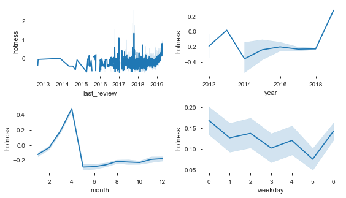

```python
fig,[(ax1,ax2),(ax3,ax4)]=plt.subplots(2,2,figsize=(9,5))#绘制对称子图,子图大小
sns.lineplot(x="last_review", y="hotness",ax=ax1,
             data=newdf)
sns.lineplot(x="year", y="hotness",ax=ax2,
             data=newdf)
sns.lineplot(x="month", y="hotness",ax=ax3,
             data=newdf)
sns.lineplot(x="weekday", y="hotness",ax=ax4,
             data=newdf)
plt.subplots_adjust(wspace=0.25,hspace=0.4) #调整子图间隙
```

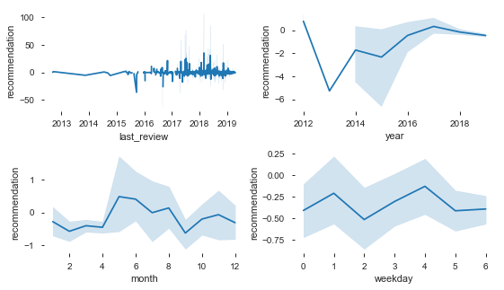

```python
fig,[(ax1,ax2),(ax3,ax4)]=plt.subplots(2,2,figsize=(9,5))#绘制对称子图,子图大小
sns.lineplot(x="last_review", y="recommendation",ax=ax1,
             data=newdf)
sns.lineplot(x="year", y="recommendation",ax=ax2,
             data=newdf)
sns.lineplot(x="month", y="recommendation",ax=ax3,
             data=newdf)
sns.lineplot(x="weekday", y="recommendation",ax=ax4,
             data=newdf)
plt.subplots_adjust(wspace=0.25,hspace=0.4) #调整子图间隙
```

分析：短租的信息从2014年开始增长，18-19年猛增；而从月份来看3-4月份是旺季，而5月之后属于淡季;从周度来看，存在一定周末效应。

```python
newdf.columns.tolist()
```

```
['id',
 'name',
 'host_id',
 'host_name',
 'neighbourhood',
 'latitude',
 'longitude',
 'room_type',
 'price',
 'minimum_nights',
 'number_of_reviews',
 'last_review',
 'reviews_per_month',
 'calculated_host_listings_count',
 'availability_365',
 'year',
 'month',
 'weekday',
 'is_workday',
 'is_holiday',
 'is_in_lieu',
 'Polarity',
 'ProbaPositive',
 'room_type__count',
 'neighbourhood__count',
 'host_id__count',
 'today',
 'last_rewtonow',
 'convenience',
 'hotness',
 'reputation',
 'experience',
 'cost_performance',
 'recommendation']
```

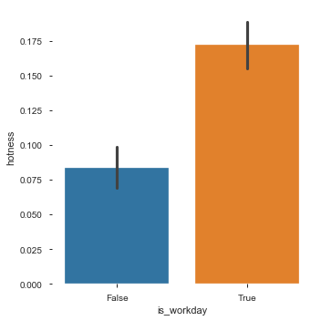

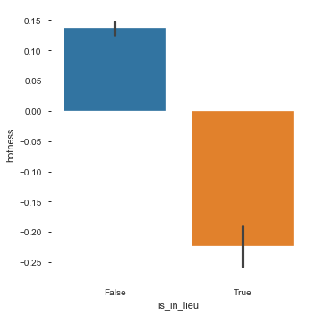

```python
sns.catplot(x="is_workday", y="hotness", kind="bar", data=newdf)
sns.catplot(x="is_in_lieu", y="hotness", kind="bar", data=newdf)
```

## 价格影响因素分析

```python
def lgb_feat_selection(df,label,k=5):
    clf = lgb.LGBMRegressor(objective='regression',metric= 'mae',silent=1,num_leaves=80,learning_rate=0.03, n_estimators=300)
    clf.fit(df.drop(label,axis=1), df[label],categorical_feature=cat_feat,verbose=0)
    keys=df.columns
    values=clf.feature_importances_
    feim=dict(zip(keys,values))
    rank=sorted(feim.items(),  key=lambda d: d[1], reverse=True) #按得分降序
    derank=sorted(feim.items(),  key=lambda d: d[1], reverse=False) #按得分升序
    rank_keys=[i[0] for i in rank][0:k]
    derank_keys=[i[0] for i in derank][0:k]
    lgb.plot_importance(clf)
    return {"Kbest":rank_keys,"kworst":derank_keys}
```

```python
newdf.info()
```

```
<class 'pandas.core.frame.DataFrame'>
Int64Index: 25815 entries, 0 to 25814
Data columns (total 34 columns):
 #   Column                          Non-Null Count  Dtype
---  ------                          --------------  -----
 0   id                              25815 non-null  int64
 1   name                            25815 non-null  category
 2   host_id                         25815 non-null  category
 3   host_name                       25815 non-null  category
 4   neighbourhood                   25815 non-null  category
 5   latitude                        25815 non-null  float16
 6   longitude                       25815 non-null  float16
 7   room_type                       25815 non-null  category
 8   price                           25815 non-null  float64
 9   minimum_nights                  25815 non-null  float64
```

[output cut: 26 more lines]

```python
cat_feat=['id',
 'name',
 'host_id',
 'host_name',
 'neighbourhood',
 'room_type',
 'is_workday',
 'is_holiday',
 'is_in_lieu']
```

```python
from sklearn.preprocessing import LabelEncoder
le = LabelEncoder()
for i in cat_feat:
    newdf[i]=le.fit_transform(newdf[i])
```

```python
newdf.drop("today",axis=1,inplace=True)
```

```python
from feature_selector import FeatureSelector
```

```python
fs = FeatureSelector(data =newdf.drop(indicator+["price"],axis=1), labels = newdf["price"])
```

```python
# Pass in the appropriate parameters
fs.identify_zero_importance(task = 'regression',  eval_metric = 'mse',
 n_iterations = 50,  early_stopping = True)
```

```python
fs.feature_importances.head(10)
```

|  | feature | importance | normalized_importance | cumulative_importance |
| --- | --- | --- | --- | --- |
| 0 | latitude | 485.34 | 0.090939 | 0.090939 |
| 1 | host_name | 468.60 | 0.087802 | 0.178741 |
| 2 | name | 434.96 | 0.081499 | 0.260240 |
| 3 | id | 428.12 | 0.080217 | 0.340457 |
| 4 | longitude | 398.86 | 0.074735 | 0.415192 |
| 5 | host_id | 393.60 | 0.073749 | 0.488941 |
| 6 | reviews_per_month | 355.04 | 0.066524 | 0.555466 |
| 7 | ProbaPositive | 337.98 | 0.063328 | 0.618793 |
| 8 | availability_365 | 294.78 | 0.055233 | 0.674027 |
| 9 | calculated_host_listings_count | 229.56 | 0.043013 | 0.717040 |

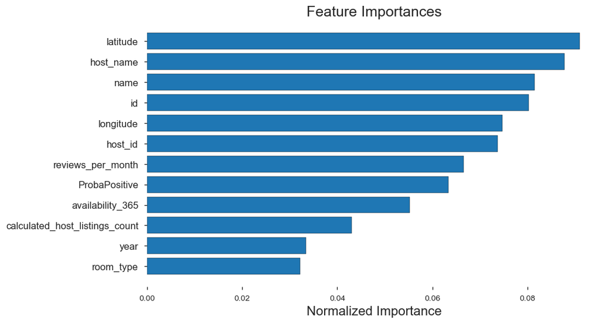

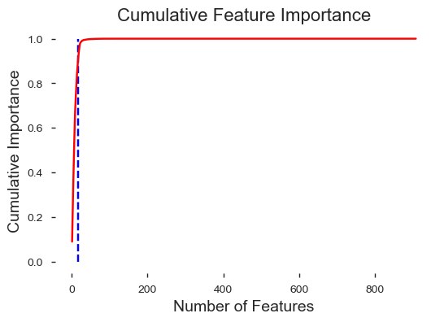

```
17 features required for 0.90 of cumulative importance
```

```python
# plot the feature importances
fs.plot_feature_importances(threshold = 0.9, plot_n = 12)
```

```python
one_hot_features = fs.one_hot_features
base_features = fs.base_features
print('There are %d original features' % len(base_features))
print('There are %d one-hot features' % len(one_hot_features))
```

```
There are 26 original features
There are 883 one-hot features
```

### 文本可视化

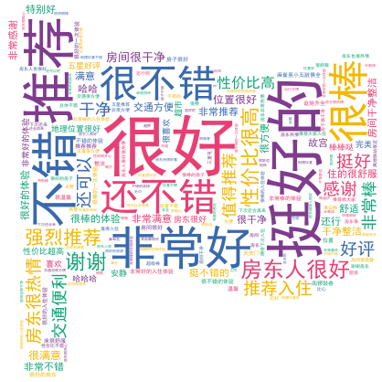

```python
from stylecloud import gen_stylecloud
from IPython.display import Image# 用于在jupyter lab中显示本地图片

gen_stylecloud(file_path="Chinese_comments.csv",#绘制词云的文本
               font_path=r'C:\Windows\Fonts\simhei.ttf',#字体路径
               custom_stopwords=excludes, #停用词表
#                palette="scientific.diverging.Broc_3",# 设置配色方案
               icon_name="fas fa-flag",# 设置图标样式,使用库内自带的引用格式为："fas fa-图标标题"
               size=418,#控制输出图像文件的分辨率,默认512
               max_font_size=75,# 设置最大字体
               output_name="stylecloud.png") #输出词云文件名

Image(filename="stylecloud.png") #调用本地图片在jupyter中显示
```

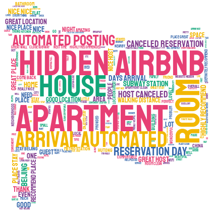

```python
gen_stylecloud(file_path="English_comments.csv",#绘制词云的文本
#                font_path=r'C:\Windows\Fonts\simhei.ttf',#字体路径
#                custom_stopwords=excludes, #停用词表
#                palette="scientific.diverging.Broc_3",# 设置配色方案
               icon_name="fas fa-flag",# 设置图标样式,使用库内自带的引用格式为："fas fa-图标标题"
               size=418,#控制输出图像文件的分辨率,默认512
               max_font_size=75,# 设置最大字体
               output_name="stylecloud-E.png") #输出词云文件名

Image(filename="stylecloud-E.png") #调用本地图片在jupyter中显示
```

分析：正面评价很多，租客对于房源满意度较高。性价比、交通、房东性格、舒适度等比较受到重视。

# 总结

- 通过对房源信息进行量化，建立了'convenience','hotness', 'reputation', 'experience', 'cost_performance', 'recommendation'等指标，挖掘最受用户欢迎的房源，实现按需推荐。
- 计算房东的质量分数，实现房东的精细化运营管理。
- 时间序列分析表明：短租的信息从2014年开始增长，18-19年猛增；而从月份来看3-4月份是旺季，而5月之后属于淡季;从周度来看，存在一定周末效应。
- 短租整体正面评价很多，租客对于房源满意度较高。性价比、交通、房东性格、舒适度等比较受到重视。